# Donor Profile: Australia - Department of Foreign Affairs and Trade

## Focus Portfolio

Resource allocation analysis uncovers significant disparities within Australia’s DFAT portfolio, with total donor funding ranging from $3.2M to $28.6M across three key UNHCR regions. Despite an average commitment near $9.5M, funding concentration heavily skews toward one region, highlighting untapped opportunities in underfunded areas. This imbalance poses a risk to unified regional resilience and emergency responsiveness, critical donor priorities. Investing in a more balanced approach can serve as an impact multiplier, enhancing effectiveness and accountability by enabling scale where gaps persist. Strategic engagement should prioritize expanding partnerships focused on mid-tier regions demonstrating funding deficits yet possessing high vulnerability profiles. Immediate allocation decisions must consider this data to optimize return on investment and mitigate risk of aid fragmentation. Donors have a clear opportunity to strategically leverage their funds for maximum collective impact by supporting a portfolio rebalance that drives resilience and innovation across all operational theaters.

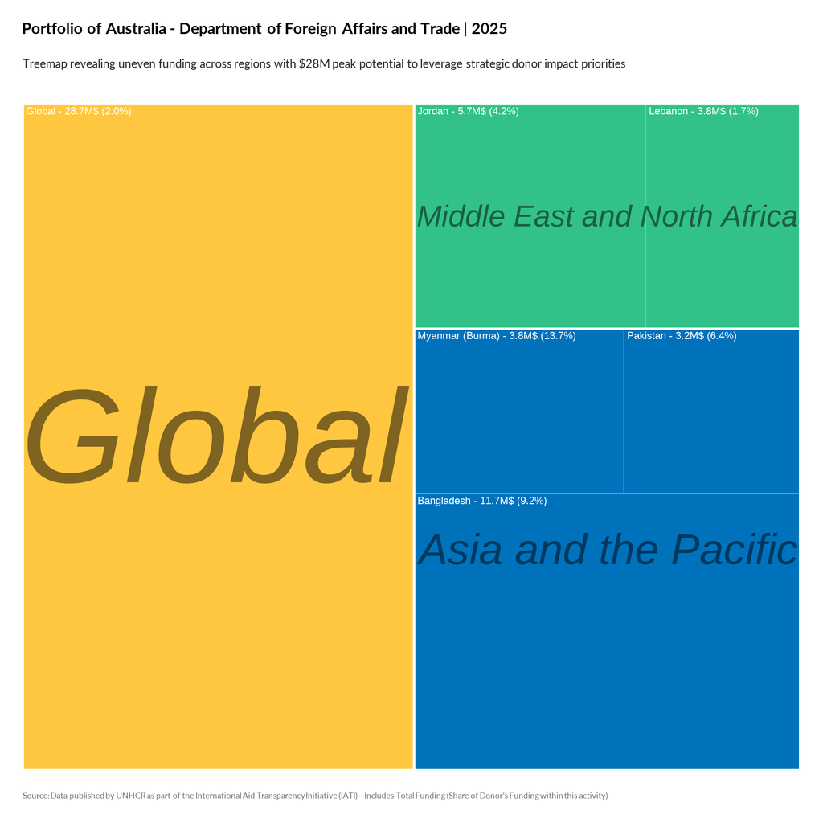

TRUE

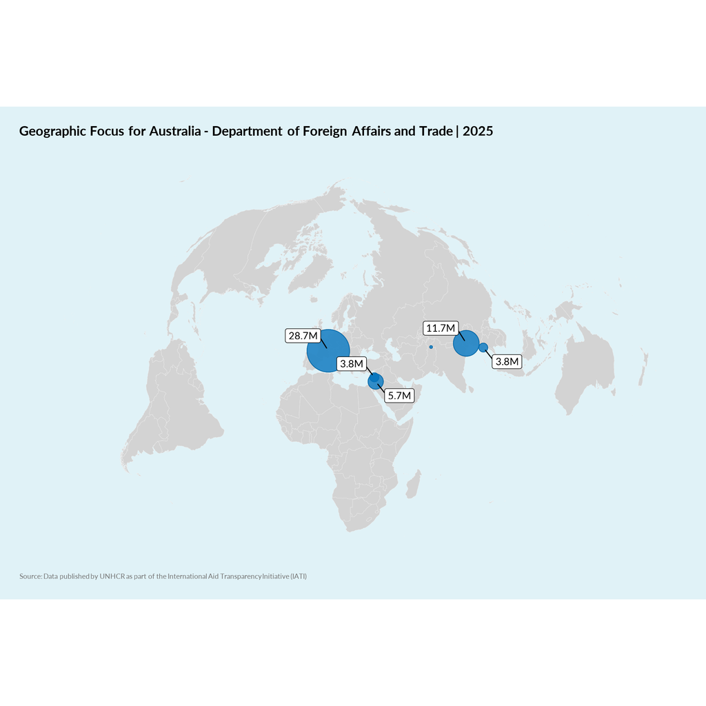

TRUE